# FA#2

2024-02-20

1. Use pivot_longer to reshape the dataset into one that has two columns, the first giving the protein identity and the second giving the amount of the protein in one of the cells. The dataset you get should have 1750000 rows (50000 cells in the original dataset times 35 proteins).
2. Use group_by and summarise to find the median protein level and the median absolute deviation of the protein level for each marker. (Use the R functions median and mad).
3. Make a plot with mad on the x-axis and median on the y-axis. This is known as a spreadlocation (s-l) plot. What does it tell you about the relationship betwen the median and the mad?

```r
library(tidyverse)
data <- read.csv("D:/desktop/cytof_one_experiment.csv")

data_long <- pivot_longer(data, cols = everything(), names_to = "Protein", values_to = "Amount")

cat("Number of rows in reshaped dataset:", nrow(data_long), "\n")
```

```
## Number of rows in reshaped dataset: 1750000
```

```r
protein_summary <- data_long %>%
  group_by(Protein) %>%
  summarise(
    Median = median(Amount, na.rm = TRUE),
    MAD = mad(Amount, constant = 1, na.rm = TRUE)
  )

print(protein_summary)
```

```
## # A tibble: 35 × 3
##    Protein  Median   MAD
##    <chr>     <dbl> <dbl>
##  1 CD107a  -0.122  0.411
##  2 CD16     5.12   0.590
##  3 CD161    0.726  1.14
##  4 CD2      3.95   1.13
##  5 CD4     -0.204  0.267
##  6 CD56     5.71   0.673
##  7 CD57     3.07   1.34
##  8 CD69     4.59   0.687
##  9 CD8      2.40   1.54
## 10 CXCR6   -0.0581 0.490
## # ℹ 25 more rows
```

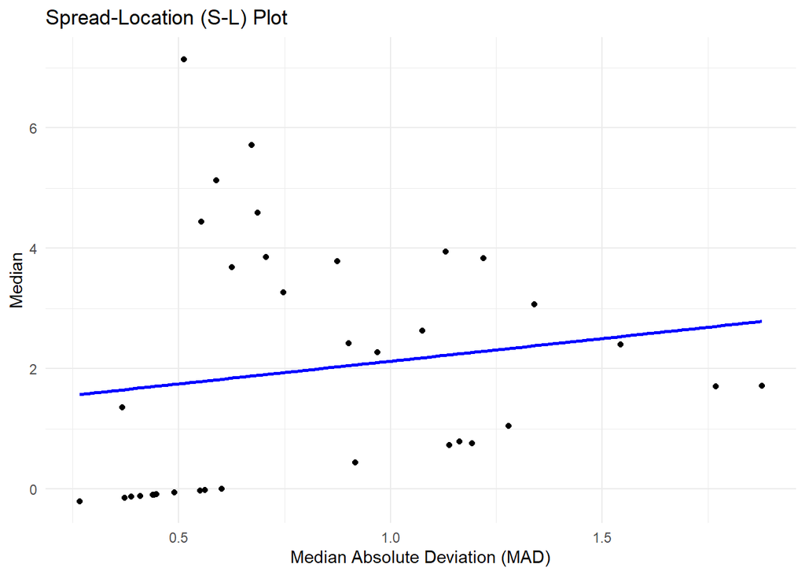

```r
library(ggplot2)

ggplot(protein_summary, aes(x = MAD, y = Median)) +
  geom_point() +
  theme_minimal() +
  labs(x = "Median Absolute Deviation (MAD)", y = "Median", title = "Spread-Location (S-L) Plot") +
  geom_smooth(method = "lm", se = FALSE, color = "blue")
```

The spread-location (s-l) plot shows the relationship between the median absolute deviation (MAD) on the x-axis and the median protein level on the y-axis for each protein. This plot helps us to understand the variability (spread) of protein levels across cells in relation to their central tendency (median).

4. Using either pivot_longer on its own or pivot_longer in combination with separate, reshape the dataset so that it has columns for country, event, year, and score.

```r
options(repos = c(CRAN = "https://mirrors.tuna.tsinghua.edu.cn/CRAN/"))

install.packages("remotes")
# Use remotes to install dcldata
remotes::install_github("dcl-docs/dcldata")
# Load the dcldata package
library(dcldata)
# Load the example_gymnastics_2 dataset
data(example_gymnastics_2)
# Reshape the dataset
library(tidyr)
library(dplyr)

reshaped_data <- example_gymnastics_2 %>%
  pivot_longer(
    -country,
    names_to = "event_year",
    values_to = "score"
  ) %>%
  separate(event_year, into = c("event", "year"), sep = "_")

# Display the first few rows of the reshaped dataset
head(reshaped_data)
```

```
## # A tibble: 6 × 4
##   country       event year  score
##   <chr>         <chr> <chr> <dbl>
## 1 United States vault 2012   48.1
## 2 United States floor 2012   45.4
## 3 United States vault 2016   46.9
## 4 United States floor 2016   46.0
## 5 Russia        vault 2012   46.4
## 6 Russia        floor 2012   41.6
```